# Python Code for Examples in Chapter 4

## Spline Basis Functions

This notebook demonstrates three common ways to construct cubic spline bases in Python:

1. A custom truncated-power (radial) cubic spline basis
2. B-spline bases via Patsy's `bs()`
3. Natural cubic spline bases via Patsy's `cr()`

We use the same evaluation grid $x \in [0,1]$ and the same three interior knots $\{1/6,\, 3/6,\, 5/6\}$ throughout for easy comparison.

### Truncated-power cubic spline basis

We first define a function that returns the full design matrix for a cubic spline expressed in a truncated-power basis. The basis consists of an intercept, a linear term, and one radial basis function $R(x,z)$ for each knot $z$.

```python
import numpy as np
import matplotlib.pyplot as plt
from patsy import dmatrix
```

```python
def R_xz(x, z):
    """Radial cubic basis function centered at knot z."""
    x = np.asarray(x)
    z = np.asarray(z)

    term1 = ((z - 0.5) ** 2 - 1 / 12) * ((x - 0.5) ** 2 - 1 / 12) / 4
    term2 = (
        (np.abs(x - z) - 0.5) ** 4
        - 0.5 * (np.abs(x - z) - 0.5) ** 2
        + 7 / 240
    ) / 24

    return term1 - term2


def cubic_spline_basis(x, knots):
    """Build the design matrix H = [1, x, R(x, z1), ..., R(x, zk)]."""
    x = np.asarray(x)
    knots = np.asarray(knots)

    H0 = np.ones_like(x)
    H1 = x
    H_knots = np.column_stack([R_xz(x, knot) for knot in knots])

    return np.column_stack([H0, H1, H_knots])
```

When fitting a regression model the same matrix $H$ serves directly as the design matrix.

We evaluate the basis on a fine grid and form a linear combination with fixed coefficients to illustrate a typical spline curve.

```python
knots = np.array([1/6, 3/6, 5/6])
x = np.linspace(0, 1, 101)

H = cubic_spline_basis(x, knots)

beta = np.array([4, -0.05, -6, 2, 10])
f = H @ beta
```

### Plots of the basis functions and of a linear combination

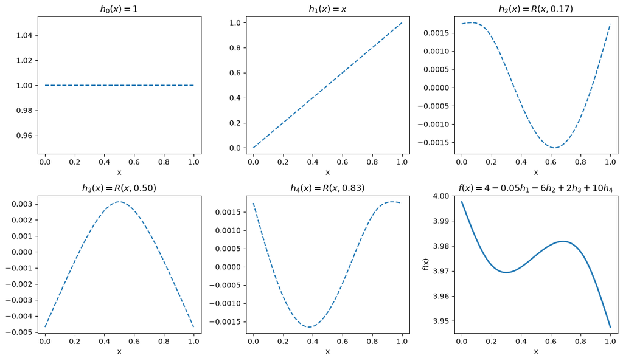

```python
fig, axes = plt.subplots(2, 3, figsize=(12, 7))
axes = axes.ravel()

labels = [
    r"$h_0(x)=1$",
    r"$h_1(x)=x$",
    rf"$h_2(x)=R(x,{knots[0]:.2f})$",
    rf"$h_3(x)=R(x,{knots[1]:.2f})$",
    rf"$h_4(x)=R(x,{knots[2]:.2f})$",
]

for j in range(5):
    axes[j].plot(x, H[:, j], linestyle="--")
    axes[j].set_title(labels[j])
    axes[j].set_xlabel("x")

axes[5].plot(x, f, linewidth=2)
axes[5].set_title(r"$f(x)=4-0.05h_1-6h_2+2h_3+10h_4$")
axes[5].set_xlabel("x")
axes[5].set_ylabel("f(x)")

plt.tight_layout()
plt.show()
```

### B-spline bases with Patsy

In Python the function `bs()` from the Patsy package constructs B-spline basis functions. It is analogous to `bs()` from R’s `splines` package and is convenient for building design matrices for regression models. See the [Patsy documentation on spline regression](https://patsy.readthedocs.io/en/latest/spline-regression.html) for further details.

#### Specifying knot locations

When the knot locations are known they can be passed directly via the `knots` argument. Below we evaluate cubic B-splines on the unit interval with interior knots at $1/6$, $3/6$ and $5/6$. The resulting design matrix contains one column for each basis function.

```python
x = np.linspace(0, 1, 101)
knots = [1/6, 3/6, 5/6]

B_splines_basis1 = dmatrix(
    "bs(x, knots=knots, degree=3, include_intercept=False, "
    "lower_bound=0, upper_bound=1) - 1",
    {"x": x, "knots": knots},
    return_type="dataframe"
)

B_splines_basis1.head(6)
```

|  | bs(x, knots=knots, degree=3, include_intercept=False, lower_bound=0, upper_bound=1)[0] | bs(x, knots=knots, degree=3, include_intercept=False, lower_bound=0, upper_bound=1)[1] | bs(x, knots=knots, degree=3, include_intercept=False, lower_bound=0, upper_bound=1)[2] | bs(x, knots=knots, degree=3, include_intercept=False, lower_bound=0, upper_bound=1)[3] | bs(x, knots=knots, degree=3, include_intercept=False, lower_bound=0, upper_bound=1)[4] | bs(x, knots=knots, degree=3, include_intercept=False, lower_bound=0, upper_bound=1)[5] |
| --- | --- | --- | --- | --- | --- | --- |
| 0 | 0.000000 | 0.000000 | 0.000000 | 0.0 | 0.0 | 0.0 |
| 1 | 0.165912 | 0.003490 | 0.000014 | 0.0 | 0.0 | 0.0 |
| 2 | 0.304896 | 0.013517 | 0.000115 | 0.0 | 0.0 | 0.0 |
| 3 | 0.418824 | 0.029419 | 0.000389 | 0.0 | 0.0 | 0.0 |
| 4 | 0.509568 | 0.050534 | 0.000922 | 0.0 | 0.0 | 0.0 |
| 5 | 0.579000 | 0.076200 | 0.001800 | 0.0 | 0.0 | 0.0 |

The trailing `- 1` in the formula removes the intercept column that Patsy adds by default, so the returned columns are exactly the B-spline basis functions.

#### Specifying degrees of freedom

Instead of listing knots explicitly one can request a desired number of degrees of freedom with the `df` argument. For cubic B-splines Patsy places the required interior knots at suitable quantiles of the observed $x$ values. With `df=4` the design matrix therefore contains four basis functions.

```python
x = np.linspace(0, 1, 101)

B_splines_basis2 = dmatrix(
    "bs(x, df=4, degree=3, include_intercept=False, "
    "lower_bound=0, upper_bound=1) - 1",
    {"x": x},
    return_type="dataframe"
)

B_splines_basis2.columns = range(1, B_splines_basis2.shape[1] + 1)

B_splines_basis2.head(6)
```

|  | 1 | 2 | 3 | 4 |
| --- | --- | --- | --- | --- |
| 0 | 0.000000 | 0.000000 | 0.000000 | 0.0 |
| 1 | 0.058214 | 0.000592 | 0.000002 | 0.0 |
| 2 | 0.112912 | 0.002336 | 0.000016 | 0.0 |
| 3 | 0.164178 | 0.005184 | 0.000054 | 0.0 |
| 4 | 0.212096 | 0.009088 | 0.000128 | 0.0 |
| 5 | 0.256750 | 0.014000 | 0.000250 | 0.0 |

#### Illustration of the B-spline basis functions

Using the same three interior knots as before we rebuild the cubic B-spline basis (101 evaluation points × 6 basis functions) and plot each function to highlight its local support.

```python
x = np.linspace(0, 1, 101)
knots = [1/6, 3/6, 5/6]

B_splines_basis = dmatrix(
    "bs(x, knots=knots, degree=3, include_intercept=False, "
    "lower_bound=0, upper_bound=1) - 1",
    {"x": x, "knots": knots},
    return_type="dataframe"
)

B_splines_basis.columns = range(1, B_splines_basis.shape[1] + 1)

print("Shape:", B_splines_basis.shape)
B_splines_basis.head(6)
```

```
Shape: (101, 6)
```

|  | 1 | 2 | 3 | 4 | 5 | 6 |
| --- | --- | --- | --- | --- | --- | --- |
| 0 | 0.000000 | 0.000000 | 0.000000 | 0.0 | 0.0 | 0.0 |
| 1 | 0.165912 | 0.003490 | 0.000014 | 0.0 | 0.0 | 0.0 |
| 2 | 0.304896 | 0.013517 | 0.000115 | 0.0 | 0.0 | 0.0 |
| 3 | 0.418824 | 0.029419 | 0.000389 | 0.0 | 0.0 | 0.0 |
| 4 | 0.509568 | 0.050534 | 0.000922 | 0.0 | 0.0 | 0.0 |
| 5 | 0.579000 | 0.076200 | 0.001800 | 0.0 | 0.0 | 0.0 |

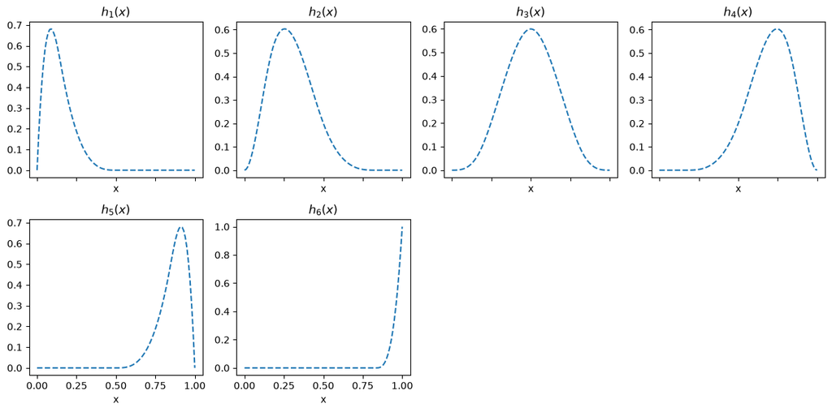

```python
fig, axes = plt.subplots(2, 4, figsize=(12, 6), sharex=True)
axes = axes.ravel()

for j, col in enumerate(B_splines_basis.columns):
    axes[j].plot(x, B_splines_basis[col], linestyle="--")
    axes[j].set_title(rf"$h_{{{col}}}(x)$")
    axes[j].set_xlabel("x")

for ax in axes[B_splines_basis.shape[1]:]:
    ax.axis("off")

plt.tight_layout()
plt.show()
```

### Natural cubic splines with Patsy

In R, natural cubic spline bases are obtained with `ns()` from the `splines` package. The Python counterpart is Patsy’s `cr()` function (usually called through `dmatrix`). `cr()` produces a natural cubic regression-spline basis that is ready to be used as a design matrix. Details are available in the [Patsy spline-regression documentation](https://patsy.readthedocs.io/en/latest/spline-regression.html).

The individual basis functions generated by Patsy need not coincide with those produced by R’s `ns()`, because spline bases are not unique. They nevertheless span the same function space and serve the same modelling purpose.

```python
x = np.linspace(0, 1, 101)
knots = [1/6, 3/6, 5/6]

NCS_basis = dmatrix(
    "cr(x, knots=knots, lower_bound=0, upper_bound=1, "
    "constraints='center') - 1",
    {"x": x, "knots": knots},
    return_type="dataframe"
)

NCS_basis.columns = range(1, NCS_basis.shape[1] + 1)

print("Shape:", NCS_basis.shape)
NCS_basis.head(6)
```

```
Shape: (101, 4)
```

|  | 1 | 2 | 3 | 4 |
| --- | --- | --- | --- | --- |
| 0 | -0.524008 | -0.660049 | -0.524008 | -0.087079 |
| 1 | -0.426435 | -0.644280 | -0.501381 | -0.084812 |
| 2 | -0.329323 | -0.628408 | -0.478891 | -0.082536 |
| 3 | -0.233134 | -0.612331 | -0.456676 | -0.080240 |
| 4 | -0.138330 | -0.595945 | -0.434874 | -0.077916 |
| 5 | -0.045371 | -0.579147 | -0.413621 | -0.075554 |

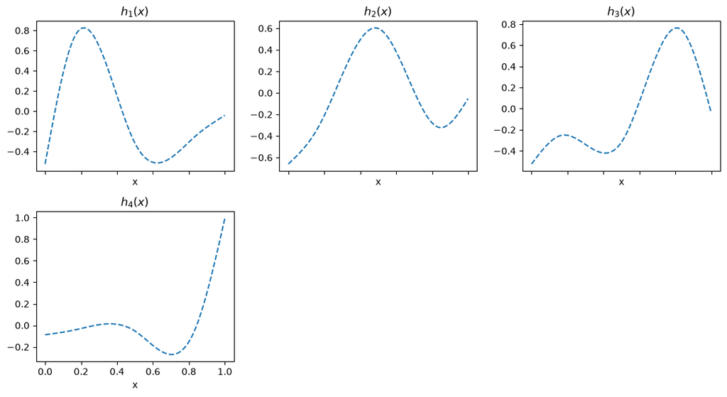

```python
fig, axes = plt.subplots(2, 3, figsize=(11, 6), sharex=True)
axes = axes.ravel()

for j, col in enumerate(NCS_basis.columns):
    axes[j].plot(x, NCS_basis[col], linestyle="--")
    axes[j].set_title(rf"$h_{{{col}}}(x)$")
    axes[j].set_xlabel("x")

for ax in axes[NCS_basis.shape[1]:]:
    ax.axis("off")

plt.tight_layout()
plt.show()
```